# K Nearest Neighbor Tutorial

Congxin (David) Xu

12/11/2020

## Description

This tutorial is going to discuss how to implement K Nearest Neighbor model in `R`.

## Package Dependency

- [`tidyverse`](https://www.tidyverse.org/)
  - We will mainly use `tidyverse` for data manipulation (`dplyr`) and visualization (`ggplot2`).
- [`FNN`](https://cran.r-project.org/web/packages/FNN/FNN.pdf)
  - Title: Fast Nearest Neighbor Search Algorithms and Applications
  - This is package that contains the `knn.reg()` function that will perform the K-Nearest-Neighbor regression

## Use Case

- Solving regression type of problem
- Fill in missing period handling

## Caution

- Do not use to predict something the training data has not seen before.
- Need to find a way to convert categorical predictors to numeric predictors.

## Tutorial

Load the required library

```r
library(tidyverse)
library(FNN)
```

The data we will use is the housing price data from [Kaggle](https://www.kaggle.com/c/house-prices-advanced-regression-techniques).

- Response Variable: **`price`**

**Read and Preview the Training Data**

```r
train <- read_csv('.\\Data\\realestate-train.csv')
head(train)
```

```
#> # A tibble: 6 x 13
#>   price PoolArea GarageCars Fireplaces TotRmsAbvGrd Baths SqFeet CentralAir
#>   <dbl>    <dbl>      <dbl>      <dbl>        <dbl> <dbl>  <dbl> <chr>
#> 1  208.        0          2          0            8     3   1710 Y
#> 2  140         0          3          1            7     1   1717 Y
#> 3  250         0          3          1            9     3   2198 Y
#> 4  143         0          2          0            5     2   1362 Y
#> 5  307         0          2          1            7     2   1694 Y
#> 6  130.        0          2          2            8     2   1774 Y
#> # ... with 5 more variables: Age <dbl>, LotSize <dbl>, BldgType <chr>,
#> #   HouseStyle <chr>, condition <dbl>
```

**Read and Preview the Testing Data**

```r
test <- read_csv('.\\Data\\realestate-test.csv')
head(test)
```

```
#> # A tibble: 6 x 12
#>   PoolArea GarageCars Fireplaces TotRmsAbvGrd Baths SqFeet CentralAir   Age
#>      <dbl>      <dbl>      <dbl>        <dbl> <dbl>  <dbl> <chr>      <dbl>
#> 1        0          2          0            6     2   1516 Y             45
#> 2        0          1          0            4     1    616 Y             85
#> 3        0          1          1            8     2   1696 Y             45
#> 4        0          2          0            6     3   1479 Y             34
#> 5        0          2          1            8     2   2217 Y             37
#> 6        0          2          1            7     4   1868 Y             23
#> # ... with 4 more variables: LotSize <dbl>, BldgType <chr>, HouseStyle <chr>,
#> #   condition <dbl>
```

**For this tutorial, we will just focus on the following predictors:**

- `SqFeet`: *numeric*
- `Age`: *numeric*
- `BldgType`: *Categorical*

**The predictors are selected based on intuition and they are somewhat random. The purpose is to show that KNN can only work with numeric variables.**

```r
train <- train %>%
  select(price, SqFeet, Age, BldgType) %>%
  mutate(BldgType = as.numeric(as.factor(BldgType)))
test <- test %>%
  select(SqFeet, Age, BldgType) %>%
  mutate(BldgType = as.numeric(as.factor(BldgType)))
```

**Running the KNN Model**

```r
# Choose a base case for 5 nearest neighbor
k = 5

# Kick Off the KNN Model
knn_model <- knn.reg(
  # Define training data
  train = train %>% select(-price),
  # Define test data, if NULL, LOOCV will be used`
  test = NULL,
  # Define response variable, use vector!
  y = train$price,
  # Define k, Default is 3
  k = k
)
print(knn_model)
```

```
#> PRESS =  2879498
#> R2-Predict =  0.6183188
```

**Report Mean Squared Error**

```r
mean((train$price - knn_model$pred)^2)
```

```
#> [1] 2482.326
```

**Use Cross Validation to find the best `k`**

```r
# Control Randomness
set.seed(666)

# Pre-defined variables
# Set the range of K
K <- 3:50

# Set the number of fold for Cross Validation
n.folds <- 10
fold <- sample(rep(1:n.folds, length = nrow(train)))

# Create a empty list to store output
output <- list()

# Iterate over folds
for (k in K) {

  # Create an empty output list
  each_k <- list()

  for (i in 1:n.folds) {
    # Assign Train and Valid
    train_cv <- train[which(fold != i),]
    valid <- train[which(fold == i),]

    # Fit KNN models
    model <- knn.reg(train = train_cv %>% select(-price),
                     test = valid %>% select(-price),
                     y = train_cv$price,
                     k = k)

    # Calculate the effective degrees of freedom
    edf <- nrow(train_cv) / k

    # Calculate the MSE for validation data
    valid.mse <- mean((valid$price - model$pred)^2)

    # Create a data frame to store the results
    each_k[[i]] <- data.frame(valid.mse = valid.mse, edf = edf, k = k, fold = i)
  }

  # Store results to the larger list
  output[[k]] <- bind_rows(each_k)
}

# Convert list to data frame
output <- bind_rows(output)

# Report the Optimal k and Corresponding estimated MSE
best <- output %>%
  group_by(k) %>%
  summarise(valid.mse = mean(valid.mse)) %>%
  filter(valid.mse == min(valid.mse))
print(best)
```

```
#> # A tibble: 1 x 2
#>       k valid.mse
#>   <int>     <dbl>
#> 1    11     2295.
```

**Review the distribution of validation MSE by K**

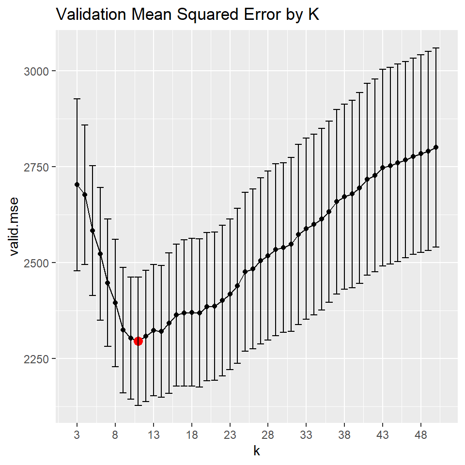

```r
# Create a plot of estimated MSE against k
output %>%
  group_by(k) %>%
  summarise(
    count = n(),
    valid.mse.se = sd(valid.mse) / sqrt(count),
    valid.mse = mean(valid.mse)
    ) %>%
  ggplot(aes(x = k, y = valid.mse)) +
  geom_point() +
  geom_line() +
  geom_point(data = . %>% filter(valid.mse == min(valid.mse)),
             color = "red",
             size = 3) +
  geom_errorbar(aes(ymin = valid.mse - valid.mse.se,
                    ymax = valid.mse + valid.mse.se)) +
  scale_x_continuous(breaks = seq(3, 50, 5)) +
  ggtitle('Validation Mean Squared Error by K')
```

**Make Prediction on test dataset**

Since we have found the best `k` value using cross validation, now we will use that value to re-train the model using the entire training data and make predictions on the test data.

```r
# Final Model
final_model <- knn.reg(
  train = train %>% select(-price),
  test = test,
  y = train$price,
  k = best$k
)

# Write the prediction to the test data
test$price <- final_model$pred
summary(test$price)
```

```
#>    Min. 1st Qu.  Median    Mean 3rd Qu.    Max.
#>   84.95  130.46  166.04  185.13  223.69  447.16
```